# An analysis of storm data

Omer

November 8, 2016

# An analysis of strorm data

**Synopsis**: Storms and other severe weather events can cause both public health and economic problems for communities and municipalities. Many severe events can result in fatalities, injuries, and property damage, and preventing such outcomes to the extent possible is a key concern.

This project involves exploring the U.S. National Oceanic and Atmospheric Administration’s (NOAA) storm database.Essentialy, we will try to answer two questions:  
1. Across the United States, which types of events are most harmful with respect to population health?  
2. Across the United States, which types of events have the greatest economic consequences?

```r
# upload needed libraries
library(dplyr)
library(tidyr)
library(ggplot2)
```

## Data overview:

The database (NOAA storm database) tracks characteristics of major storms and weather events in the United States, including when and where they occur, as well as estimates of any fatalities, injuries, and property damage. More information may be found here: https://d396qusza40orc.cloudfront.net/repdata%2Fpeer2_doc%2Fpd01016005curr.pdf

Loading and scanning the database:

```r
# check if the data file exists, if not download it
fileURL='https://d396qusza40orc.cloudfront.net/repdata%2Fdata%2FStormData.csv.bz2'
zipFile='repdata%2Fdata%2FStormData.csv.bz2'
dataFile='repdata%2Fdata%2FStormData.csv'
if (!file.exists(dataFile)){
       if (!file.exists(zipFile)){
               setInternet2(T)
               download.file(fileURL,zipFile,method='auto')
       }
        zip.unpack(zipFile,dataFile)
}
data<-read.csv(dataFile)
# dimensions of the data
dim(data)
```

```
## [1] 902297     37
```

```r
# get a sense of how the data is structured
str(data)
```

```
## 'data.frame':    902297 obs. of  37 variables:
##  $ STATE__   : num  1 1 1 1 1 1 1 1 1 1 ...
##  $ BGN_DATE  : Factor w/ 16335 levels "1/1/1966 0:00:00",..: 6523 6523 4242 11116 2224 2224 2260 383 3980 3980 ...
##  $ BGN_TIME  : Factor w/ 3608 levels "00:00:00 AM",..: 272 287 2705 1683 2584 3186 242 1683 3186 3186 ...
##  $ TIME_ZONE : Factor w/ 22 levels "ADT","AKS","AST",..: 7 7 7 7 7 7 7 7 7 7 ...
##  $ COUNTY    : num  97 3 57 89 43 77 9 123 125 57 ...
##  $ COUNTYNAME: Factor w/ 29601 levels "","5NM E OF MACKINAC BRIDGE TO PRESQUE ISLE LT MI",..: 13513 1873 4598 10592 4372 10094 1973 23873 24418 4598 ...
##  $ STATE     : Factor w/ 72 levels "AK","AL","AM",..: 2 2 2 2 2 2 2 2 2 2 ...
##  $ EVTYPE    : Factor w/ 985 levels "   HIGH SURF ADVISORY",..: 834 834 834 834 834 834 834 834 834 834 ...
##  $ BGN_RANGE : num  0 0 0 0 0 0 0 0 0 0 ...
##  $ BGN_AZI   : Factor w/ 35 levels "","  N"," NW",..: 1 1 1 1 1 1 1 1 1 1 ...
##  $ BGN_LOCATI: Factor w/ 54429 levels "","- 1 N Albion",..: 1 1 1 1 1 1 1 1 1 1 ...
##  $ END_DATE  : Factor w/ 6663 levels "","1/1/1993 0:00:00",..: 1 1 1 1 1 1 1 1 1 1 ...
##  $ END_TIME  : Factor w/ 3647 levels ""," 0900CST",..: 1 1 1 1 1 1 1 1 1 1 ...
##  $ COUNTY_END: num  0 0 0 0 0 0 0 0 0 0 ...
```

[output cut: 23 more lines]

At this point it’s important to notice that for economic related damages the value is devided to a number (‘…DMG’ tag, containing a numeric value) and a magnitude (‘…DMGEXP’ tag, containig an ebbreviation for hundred, thousand, million or billion). To understand this further the tags need to be further observed: To do that we first need to understand the ‘…DMGEXP’ rows:

```r
summary(data$PROPDMGEXP)
```

```
##             -      ?      +      0      1      2      3      4      5
## 465934      1      8      5    216     25     13      4      4     28
##      6      7      8      B      h      H      K      m      M
##      4      5      1     40      1      6 424665      7  11330
```

```r
summary(data$CROPDMGEXP)
```

```
##             ?      0      2      B      k      K      m      M
## 618413      7     19      1      9     21 281832      1   1994
```

The alphabetical character tags (m,M,h,k etc.) are clear enough. It can be assumed that the numeric tags reffer to the power of 10, but the other tags are unclear. Let’s check the percentage of these tags:

```r
magValues<-c('h','H','k','K','m','M','b','B','','0','1','2','3','4','5','6','7','8')
# for property
mean(!(data$PROPDMGEXP %in% magValues))*100
```

```
## [1] 0.001551596
```

```r
# for crop
mean(!(data$PROPDMGEXP %in% magValues))*100
```

```
## [1] 0.001551596
```

Both less than a hundredth of a percent so we’ll just ignore these values (refer to them as zeros).

## Data processing

**Obtain real values of economic damage**  
Switch the magnitude tags with numeric values of magnitude (power of ten):

```r
# for property
levels(data$PROPDMGEXP)<-c(levels(data$PROPDMGEXP),'9')
data$PROPDMGEXP[!(data$PROPDMGEXP%in%magValues)||(data$PROPDMGEXP=='')]<-'0'
data$PROPDMGEXP[data$PROPDMGEXP%in%c('h','H')]<-'2'
data$PROPDMGEXP[data$PROPDMGEXP%in%c('k','K')]<-'3'
data$PROPDMGEXP[data$PROPDMGEXP%in%c('m','M')]<-'6'
data$PROPDMGEXP[data$PROPDMGEXP%in%c('b','B')]<-'9'
# for crop
levels(data$CROPDMGEXP)<-c(levels(data$CROPDMGEXP),'3','6','9')
data$CROPDMGEXP[!(data$CROPDMGEXP%in%magValues)||(data$CROPDMGEXP=='')]<-'0'
data$CROPDMGEXP[data$CROPDMGEXP%in%c('h','H')]<-'2'
data$CROPDMGEXP[data$CROPDMGEXP%in%c('k','K')]<-'3'
data$CROPDMGEXP[data$CROPDMGEXP%in%c('m','M')]<-'6'
data$CROPDMGEXP[data$CROPDMGEXP%in%c('b','B')]<-'9'
```

Replace the numeric values with actual sums:

```r
data$PROPDMG<-with(data,PROPDMG*10^as.numeric(PROPDMGEXP))
data$CROPDMG<-with(data,PROPDMG*10^as.numeric(CROPDMGEXP))
```

Summarize the interesting variables by groups of event types:

```r
sumByEVTYPE<-data %>% group_by(EVTYPE) %>% summarise_each(funs(sum),CROPDMG,PROPDMG,INJURIES,FATALITIES)
```

Add columns to summarize the ‘cost’ of events, economicaly and health-wise, for ordering purposes:

```r
sumByEVTYPE$HEALTH<-sumByEVTYPE$FATALITIES+sumByEVTYPE$INJURIES
sumByEVTYPE$ECONOMIC<-sumByEVTYPE$CROPDMG+sumByEVTYPE$PROPDMG
```

Combining some overlapping data[^1]:

```r
# combine leading thunderstorm tags
sumByEVTYPE[sumByEVTYPE$EVTYPE=='THUNDERSTORM WIND',-1]=
        sumByEVTYPE[sumByEVTYPE$EVTYPE=='THUNDERSTORM WIND',-1]+
        sumByEVTYPE[sumByEVTYPE$EVTYPE=='THUNDERSTORM WINDS',-1]+
        sumByEVTYPE[sumByEVTYPE$EVTYPE=='TSTM WIND',-1]
# 'delete' old values
sumByEVTYPE[sumByEVTYPE$EVTYPE=='THUNDERSTORM WINDS',-1]=0
sumByEVTYPE[sumByEVTYPE$EVTYPE=='TSTM WIND',-1]=0
# combine leading heat tags
sumByEVTYPE[sumByEVTYPE$EVTYPE=='EXCESSIVE HEAT',-1]=
        sumByEVTYPE[sumByEVTYPE$EVTYPE=='EXCESSIVE HEAT',-1]+
        sumByEVTYPE[sumByEVTYPE$EVTYPE=='HEAT',-1]
# 'delete' old values
sumByEVTYPE[sumByEVTYPE$EVTYPE=='HEAT',-1]=0
```

Observe the data structure obtained:

```r
summary(sumByEVTYPE)
```

```
##                    EVTYPE       CROPDMG             PROPDMG
##     HIGH SURF ADVISORY:  1   Min.   :0.000e+00   Min.   :0.000e+00
##   COASTAL FLOOD       :  1   1st Qu.:0.000e+00   1st Qu.:0.000e+00
##   FLASH FLOOD         :  1   Median :0.000e+00   Median :0.000e+00
##   LIGHTNING           :  1   Mean   :2.801e+22   Mean   :2.801e+19
##   TSTM WIND           :  1   3rd Qu.:5.000e+12   3rd Qu.:5.000e+09
##   TSTM WIND (G45)     :  1   Max.   :1.225e+25   Max.   :1.225e+22
##  (Other)              :979
##     INJURIES         FATALITIES          HEALTH         ECONOMIC
##  Min.   :    0.0   Min.   :   0.00   Min.   :    0   Min.   :0.000e+00
##  1st Qu.:    0.0   1st Qu.:   0.00   1st Qu.:    0   1st Qu.:0.000e+00
##  Median :    0.0   Median :   0.00   Median :    0   Median :0.000e+00
##  Mean   :  142.7   Mean   :  15.38   Mean   :  158   Mean   :2.803e+22
##  3rd Qu.:    0.0   3rd Qu.:   0.00   3rd Qu.:    0   3rd Qu.:5.005e+12
##  Max.   :91346.0   Max.   :5633.00   Max.   :96979   Max.   :1.226e+25
##
```

## Results

### **Q1:** Across the United States, which types of events are most harmful with respect to population health?

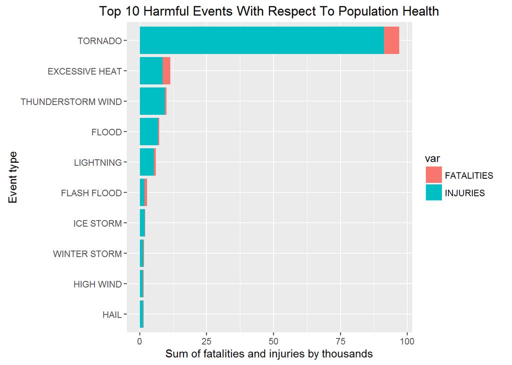

```r
# find top ten most harmful to health events
toptenHealth<-head(sumByEVTYPE[order(sumByEVTYPE$HEALTH,decreasing=T),],10)
# melt to ease ploting with detail
toptenHealth<-gather(toptenHealth,var,val,c(INJURIES,FATALITIES))
# plot
g1<-ggplot(toptenHealth, aes(x = reorder(EVTYPE, HEALTH), y = val/1000, fill=var))+
        geom_bar(stat = 'identity')+coord_flip()+
        xlab('Event type')+ylab('Sum of fatalities and injuries by thousands')+
        ggtitle("Top 10 Harmful Events With Respect To Population Health")
print(g1)
```

### **Q2:** Across the United States, which types of events have the greatest economic consequences?

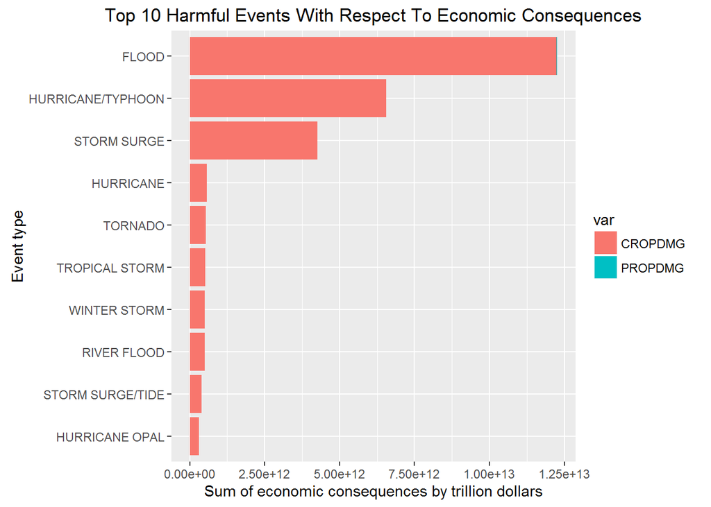

```r
# find top ten most harmful to health events
toptenEconomic<-head(sumByEVTYPE[order(sumByEVTYPE$ECONOMIC,decreasing=T),],10)
# melt to ease ploting with detail
toptenEconomic<-gather(toptenEconomic,var,val,c(CROPDMG,PROPDMG))
# plot
g2<-ggplot(toptenEconomic, aes(x = reorder(EVTYPE, ECONOMIC), y = val/(10^12), fill=var))+
        geom_bar(stat = 'identity')+coord_flip()+
        xlab('Event type')+ylab('Sum of economic consequences by trillion dollars')+
        ggtitle("Top 10 Harmful Events With Respect To Economic Consequences")
print(g2)
```

#### Footnotes:

[^1]: I noticed durring the process that some events appear more than once under different names. This is easily observed here:

    ```r
    sumByEVTYPE$EVTYPE
    ```

    ```
    ##   [1]    HIGH SURF ADVISORY           COASTAL FLOOD
    ##   [3]  FLASH FLOOD                    LIGHTNING
    ##   [5]  TSTM WIND                      TSTM WIND (G45)
    ##   [7]  WATERSPOUT                     WIND
    ##   [9] ?                              ABNORMAL WARMTH
    ##  [11] ABNORMALLY DRY                 ABNORMALLY WET
    ##  [13] ACCUMULATED SNOWFALL           AGRICULTURAL FREEZE
    ##  [15] APACHE COUNTY                  ASTRONOMICAL HIGH TIDE
    ##  [17] ASTRONOMICAL LOW TIDE          AVALANCE
    ##  [19] AVALANCHE                      BEACH EROSIN
    ##  [21] Beach Erosion                  BEACH EROSION
    ##  [23] BEACH EROSION/COASTAL FLOOD    BEACH FLOOD
    ##  [25] BELOW NORMAL PRECIPITATION     BITTER WIND CHILL
    ##  [27] BITTER WIND CHILL TEMPERATURES Black Ice
    ##  [29] BLACK ICE                      BLIZZARD
    ```

    [output cut: 479 more lines]